# Math 298: Lecture 1

#### Example 1: Discretization error This example illustrates the effects of discretization error in computing a finite difference derivative to $f(x) = \sin(x)$

First need to import the necessary libraries

```python
%matplotlib inline
import numpy as np
import matplotlib.pyplot as plt
```

```python
n = 20
x = np.ones(n) # create an array of ones
```

```python
x = math.pi*x  # pick an "arbitrary" point to evaluate derivative at
```

First we will need to create an array that will hold the different values of the step size. Here I start by initializing $h_0 = 0.1$ and then raising that value to powers in the range $0, 1, 2, 3, ..., 19$

```python
h0   = 0.1*np.ones(n)
h    = h0**np.arange(n) # create an array of increasingly smaller h values
```

Now compute the value of the forward finite difference derivative as well as the error. Note that for $sin(x)$ we know the exact derivative, i.e. $cos(x)$, so we can compute the exact error

```python
yhat = (sin(x+h) - sin(x))/h # compute finite difference
err  = abs(yhat - cos(x))    # compute error in numerical approximation
```

Now let's plot the results and see how well we did

```
<function matplotlib.pyplot.show>
```

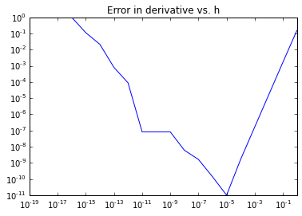

```python
plt.loglog(h,err) # Now plot the results
plt.title('Error in derivative vs. h')
plt.show
```

Save figure for later viewing

```python
plt.savefig('Lect1-fig1.png')
```

There are of course other methods for computing finite differences. You may want to play around with some of them!